# Business Analysis Report: Olist E-Commerce Platform

An Investigation into Customer Satisfaction and Negative Review Drivers

Qi Shi

November 04, 2025

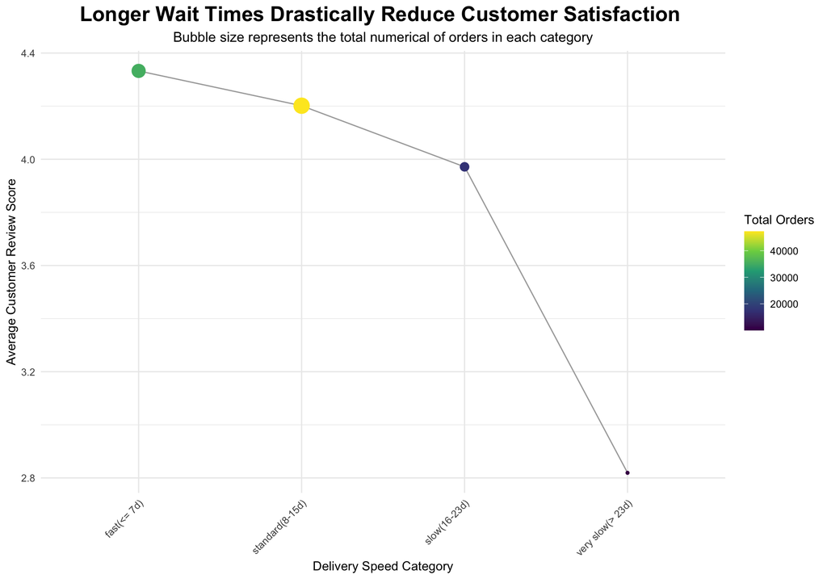

```r
# visualize the impact of wait time (categorical) on review scores,weighting by order volume.

# data preparation: define factor order
# Re-level the categorical X-axis from default alphabetical
# to a logical time progression. This is critical for geom_line()
logistics_performance$delivery_status <- factor(logistics_performance$delivery_status, levels = c("fast(<= 7d)", "standard(8-15d)", "slow(16-23d)", "very slow(> 23d)"))
# visualization
# generate the final ,polished the chart.
plot_1 <-
  ggplot(data=logistics_performance,
       # map core aesthetics. `group = 1` ensures geom_line() connects
       # all points across the categorical x-axis.
       aes(x = delivery_status, y = avg_review_score, group = 1)) +
  # geometric Layers
  # layer 1: a subtle line to establish the trend.
  geom_line(color = "darkgrey") +
  # layer 2: points (bubbles).
  # `size` and `color` are both mapped to `total_orders` for
  # redundant encoding, emphasizing the weight of each data point.
         geom_point(aes(size = total_orders, color = total_orders)) +
  # labels and narrative
  labs(
    title = "Longer Wait Times Drastically Reduce Customer Satisfaction ",
subtitle = "Bubble size represents the total numerical of orders in each category",
x = "Delivery Speed Category",
y = "Average Customer Review Score",
size = "Total Orders",
color = "Total Orders"
) +
  # scales and Themes
  # use the viridis color scale: perceptually uniform and colorblind-friendly.
  scale_color_viridis_c()+
  # start with a clean, minimal theme (white background).
  theme_minimal()+
  #thematic overrides
  theme(
    # center-align title and subtitle for a professional report look.
    plot.title = element_text(size = 18, face = "bold", hjust = 0.5),
    plot.subtitle = element_text(size = 12, hjust = 0.5),
    # final fix ---
    # rotate x-axis labels to prevent overlap.
    axis.text.x = element_text(angle = 45, hjust = 1)
  )+
  # legend management
  # remove the redundant `size` legend, keeping only the `color` legend.
  guides(size = "none")
# display the plot
plot_1
```

**Chart Analysis (Plot 1: Logistics Wait Time vs. Satisfaction):**

This chart shows the direct impact of logistics waiting time (in days) on customer satisfaction (review score). A clear negative correlation was found: as waiting time increases, average customer satisfaction steadily declines.

A key tipping point appears around the **23-day mark**; once this threshold is crossed, satisfaction drops sharply below the 3-point “passing” line, indicating customer patience has reached its limit. This finding confirms that “logistics efficiency” is one of the core drivers of bad reviews and **established `1. Delivery Issue` as a key theme, which was subsequently validated in the final heatmap analysis.**

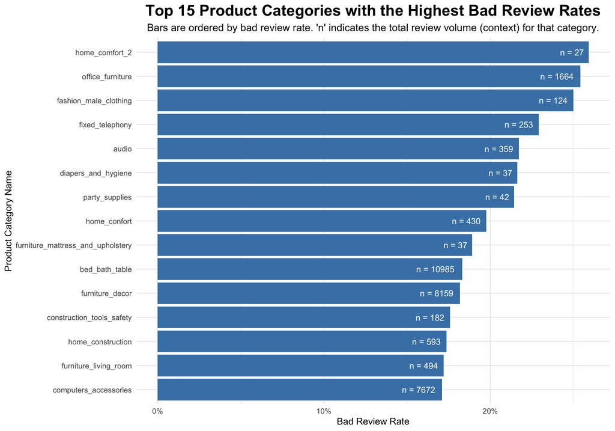

```r
# The SQL-aggregated data (`product_review_analysis`) uses Portuguese
# category names. To make the chart readable, we must join it
# with the `category_translation` dictionary table.
Top_15_bad_reviews <-
  product_review_analysis %>%
  left_join(
    product_category_name_translation,
    by = "product_category_name") %>%
  slice_max(
    order_by = bad_review_rate ,
    n= 15
  )
# visualization
# generate the final ,polished bar chart.
plot_2 <-
  ggplot(data= Top_15_bad_reviews,
         # asethetic mappings:
         #x-axis: the core metric,bad_review-rate
         #y-axis: reorder categories by bad_review_rate for intuitive ranking
         aes(x = fct_reorder(product_category_name_english, bad_review_rate), y = bad_review_rate))+
  # geometric layers:
  # layer 1: the bars.
  geom_col(fill = "steelblue")+
  # layer 2: text labels.placed inside the bars for clean look
  # the label communicates the sample size 'n',providing critical context.
  geom_text(aes(label = paste0("n = ", total_reviews)),
            hjust = 1.2, #position text slightly left of the bar's end
            color = "white", # white text is always readable on a steelblue background
            size = 3.5) +
  # labels, title, and narrative:
  labs(
    title = "Top 15 Product Categories with the Highest Bad Review Rates",
    subtitle = "Bars are ordered by bad review rate. 'n' indicates the total review volume (context) for that category.",
    y = "Bad Review Rate",
    x = "Product Category Name",
  ) +
  # format the bad review rate labels as percentages for clear communication.
  scale_y_continuous(labels = scales::percent)+
  # flip the x-axis labels as percentages for clear communication
  coord_flip()+
  # theme and final polish:
  theme_minimal() +
  theme(
    plot.title = element_text(size = 18, face = "bold", hjust = 0.5), # Center the main title
    plot.subtitle = element_text(size = 12, hjust = 0.5) # Center the subtitle
  )
# display the plot
plot_2
```

**Chart Analysis (Plot 2: Top 15 Bad Review Categories):**

This bar chart identifies the 15 product categories with the highest bad review rates (scores 1-2) on the platform, after filtering for statistical significance (min. 20 reviews).

This discovery is critical, as it reveals that poor customer satisfaction is **not** a platform-wide problem, but is **highly concentrated** in a few specific business areas (e.g., `office_furniture`, `computers_accessories`). This provided a clear focus for our deep-dive analysis.